# Tutorial: Gráficos em `R` usando o pacote `ggplot`

# Gráficos para visualização de dados.

```r
library(ggplot2)
mtcars$am <- factor(mtcars$am)
mtcars$vs <- factor(mtcars$vs)
mtcars$cyl <- factor(mtcars$cyl)
```

Neste tutorial vamos criar gráficos para variáveis qualitativas ou quantitativas usando um pacote do software R chamado ggplot2. O pacote ggplot2 tem uma função principal chamada `ggplot`, dentro desta função nós declaramos o data frame que iremos usar juntamente de funções auxiliares que servirão para incrementar os nossos gráficos. Vamos em seguida explicar o funcionamento das funções usadas nos exemplos seguintes.

## Gráficos para variáveis nominais.

Começaremos este tutorial com uma variável que podemos considerar como a do tipo mais simples: qualitativa nominal. A variável que usaremos será `vs` do banco de dados `mtcars`.

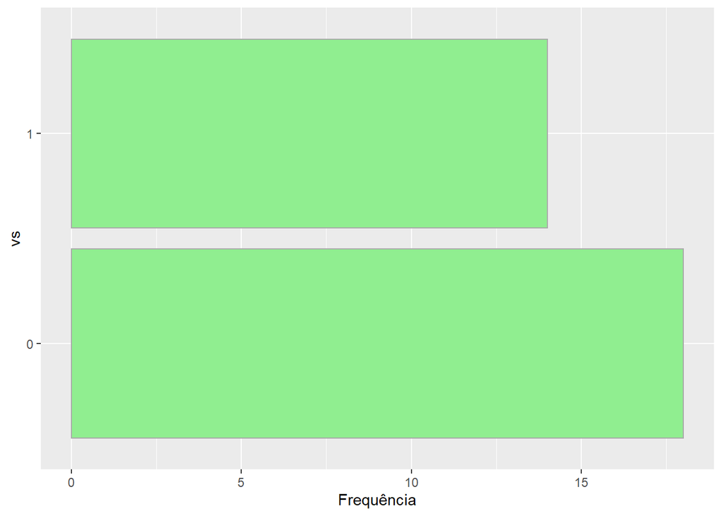

```r
ggplot(mtcars, aes(vs)) + # o argumento `aes` controla a estética do gráfico, aqui colocamos as váriveis que estamos interessados em estudar.
  geom_bar(fill = "lightgreen", colour = "darkgrey") +  # `geom_bar` é umas das funções auxiliares do pacote ggplot2, usamos `geom_bar` para declarar o formato que queremos nosso gráfico: em barras. usamos `fill` para declararmos a cor que será usada para preencher as barras e usamos `colour` para declarar a cor das linhas do gráfico.
  labs(y="Frequência") + # `labs` é uma função auxiliar que adiciona legendas a um gráfico.
  coord_flip() # `coord_flip` é uma função auxiliar que troca o eixo em que o gráfico será apresentado. Neste caso trocamos a apresentação do formato horizontal para o formato vertical.
```

O segundo tipo de gráfico que podemos usar para representar variáveis nominais é o gráfico de Setores, mais conhecido como gráfico de Pizza.

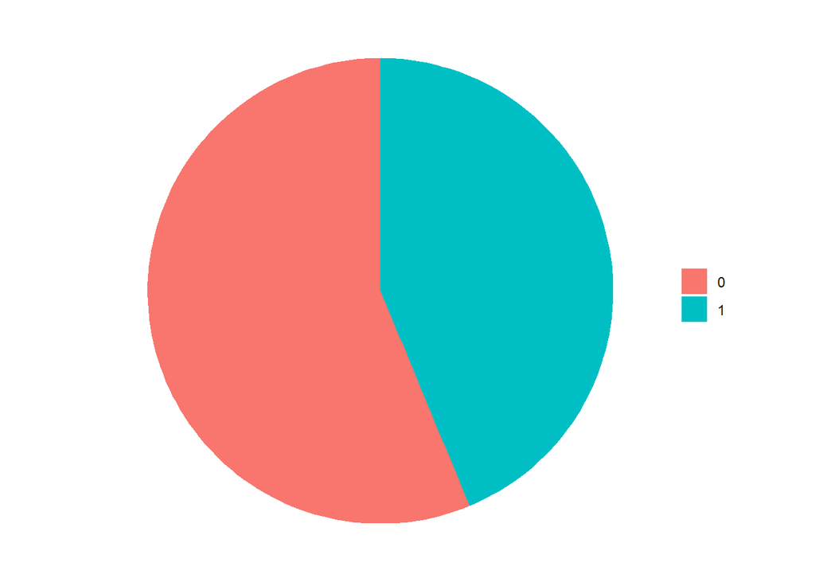

```r
  ggplot(mtcars, aes(x = factor(1), fill = factor(vs))) +
  geom_bar(stat = "count", width = 1) +
  coord_polar(theta = "y", start = 0) +
  # `coord_polar` é uma função que faz com que nosso gráfico seja apresentado em coordenadas polares.
  theme_void() +
  # `theme` é uma função usada para fazer o gráfico apresentar temas, cores e formatos pré-programados (o tema pré-programado é chamado "void")
  guides(fill=guide_legend(title=NULL))
```

```r
  # Usamos a função acima para retirar todos titulos e legendas do gráfico
```

## Gráficos para váriaveis ordinais.

Agora usaremos outra váriavel qualitaiva para criarmos nossos gráficos. A variável escolhida é `cyl` do banco de dados `mtcars` e é do tipo qualitativa ordinal.

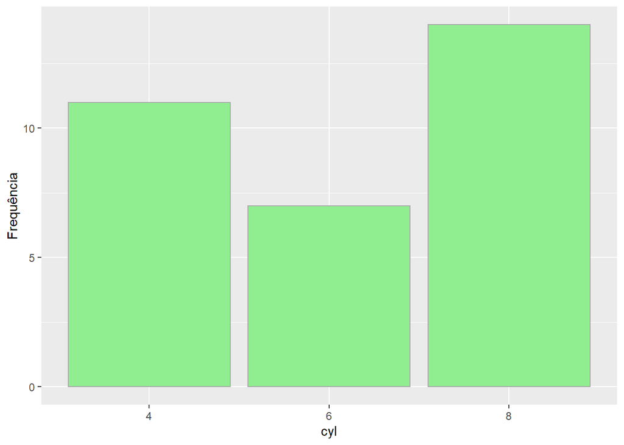

```r
  ggplot(mtcars, aes(cyl)) +
  geom_bar( fill = "lightgreen", colour = "darkgrey") +
  labs(y="Frequência")
```

O segundo tipo de gráfico que podemos usar para representar variáveis ordinais será o de Setores (Pizza).

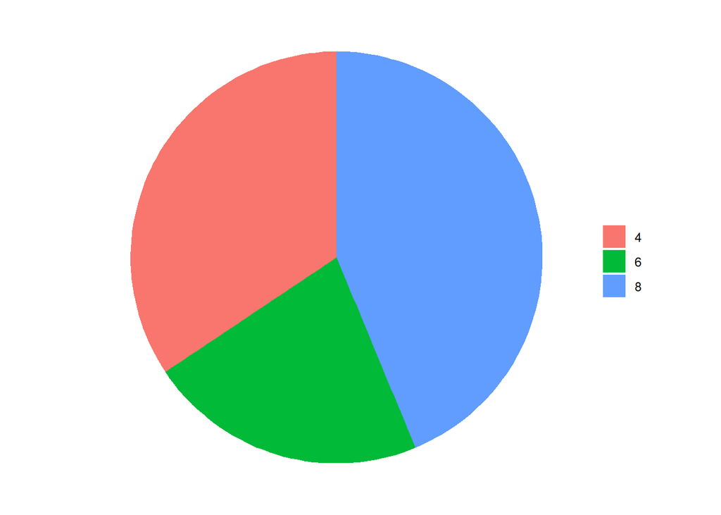

```r
  ggplot(mtcars, aes(x = factor(1), fill = factor(cyl))) +
  geom_bar(stat = "count", width = 1) +
  coord_polar(theta = "y", start = 0) +
  theme_void() +
  guides(fill=guide_legend(title=NULL))
```

## Gráficos para váriaveis discretas

Agora usaremos uma variável quantitativa para fazermos nossos gráficos. A variável usada é `carb` do banco de dados `mtcars` e é do tipo quantitativa discreta.

O primeiro tipo de gráfico que podemos usar para representar variáveis discretas será o Histograma.

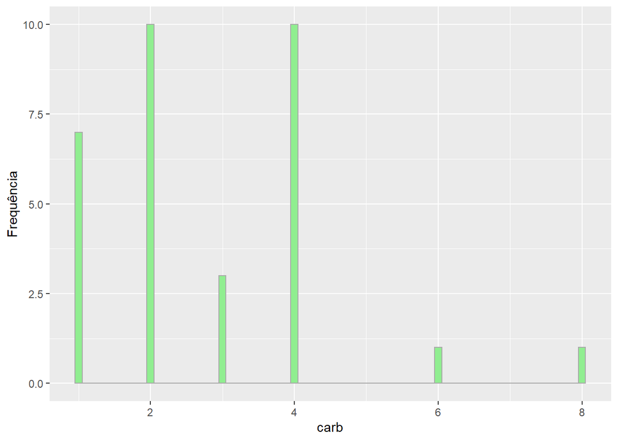

```r
  ggplot(mtcars, aes(x = carb)) +
  geom_histogram(fill = "lightgreen" ,colour = "darkgrey", binwidth = 0.1) +
  # Usamos geom_histogram para declarar o formato que queremos nosso gráfico: em formato de histograma `binwidth` faz com que as barras do histograma tenham o tamanho específico : 0.1 .
  ylab("Frequência")
```

O segundo tipo de gráfico que podemos usar para representar variáveis discretas será o de Densidade.

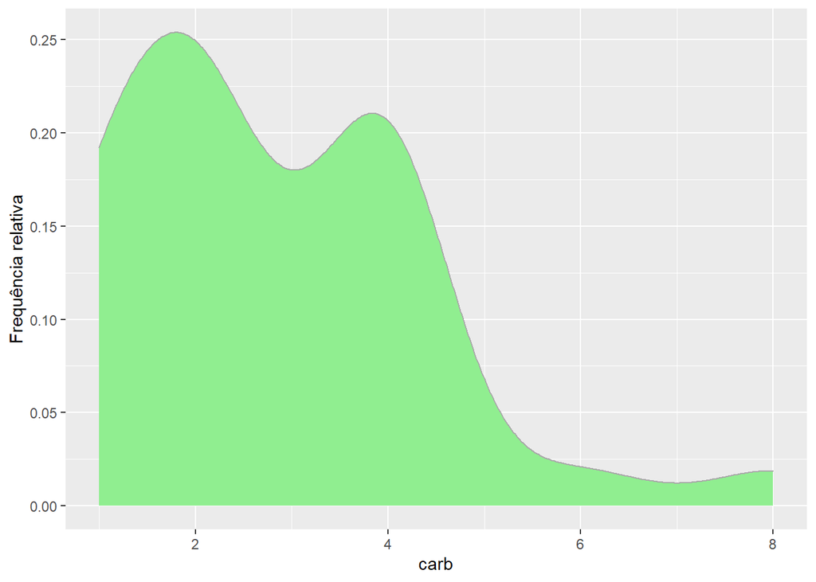

```r
  ggplot(mtcars, aes(x = carb)) +
  geom_density(fill = "lightgreen" ,colour = "darkgrey") +
  # Usamos geom_density para declarar o formato que queremos nosso gráfico: em formato de densidade.
  ylab("Frequência relativa")
```

O terceiro tipo de gráfico que podemos usar para representar variáveis discretas será o Polígono de frequência

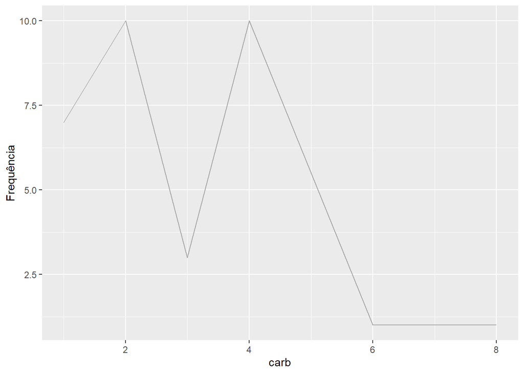

```r
  ggplot(mtcars, aes(x = carb, y = )) +
  geom_freqpoly(colour = "darkgrey", stat = "count") +
  # Usamos geom_freqpoly para declarar o formato que queremos nosso gráfico: em formato de polígono de frequência.
  ylab("Frequência")
```

Vale destacar que os gráficos do tipo Histograma, Densidade e Polígono de frequência tem uma base de construção semelhante mas, são finalizados com aparências e formatos notavelmente diferentes.

O quarto tipo de gráfico que podemos usar para representar variáveis discretas é o Boxplot.

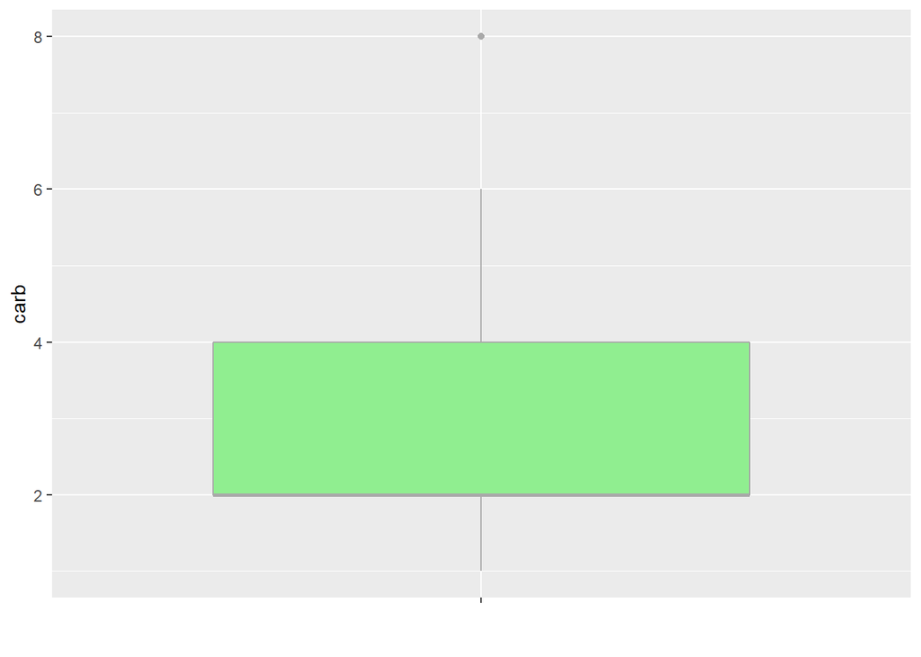

```r
  ggplot(mtcars, aes(x = "" , y = carb)) +
  geom_boxplot(fill = "lightgreen", colour = "darkgrey") +
  # Usamos geom_boxplot para declarar o formato que queremos nosso gráfico: em formato de boxplot
  xlab("")
```

O quinto tipo de gráfico que podemos usar para representar variáveis discretas é o de Distribuição Acumulada.

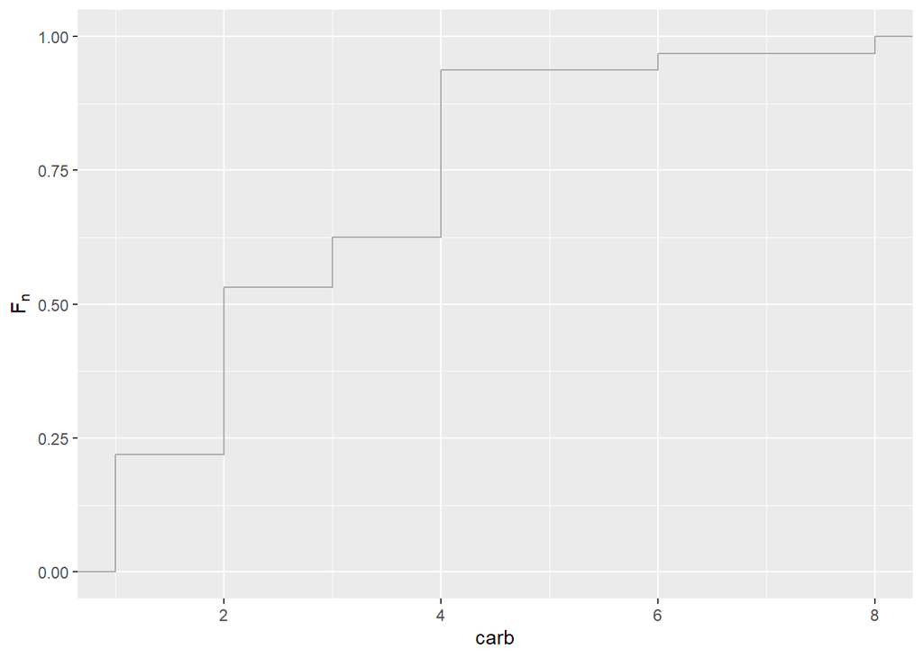

```r
  ggplot(mtcars, aes(carb)) +
  stat_ecdf(geom = "step", colour = "darkgrey") +
  # A função `stat_ecd` com o argumento geom = "step" cria um gráfico de linha com a soma acumulada da variável.
  ylab(expression(F[n]))
```

## Gráficos para váriaveis contínuas.

Agora usaremos outras variável quantitativa para fazermos nossos gráficos. A variável usada é `wt` do banco de dados `mtcars` e é do tipo quantitativa contínua.

O primeiro tipo de gráfico que podemos usar para representar variáveis contínuas é o Histograma.

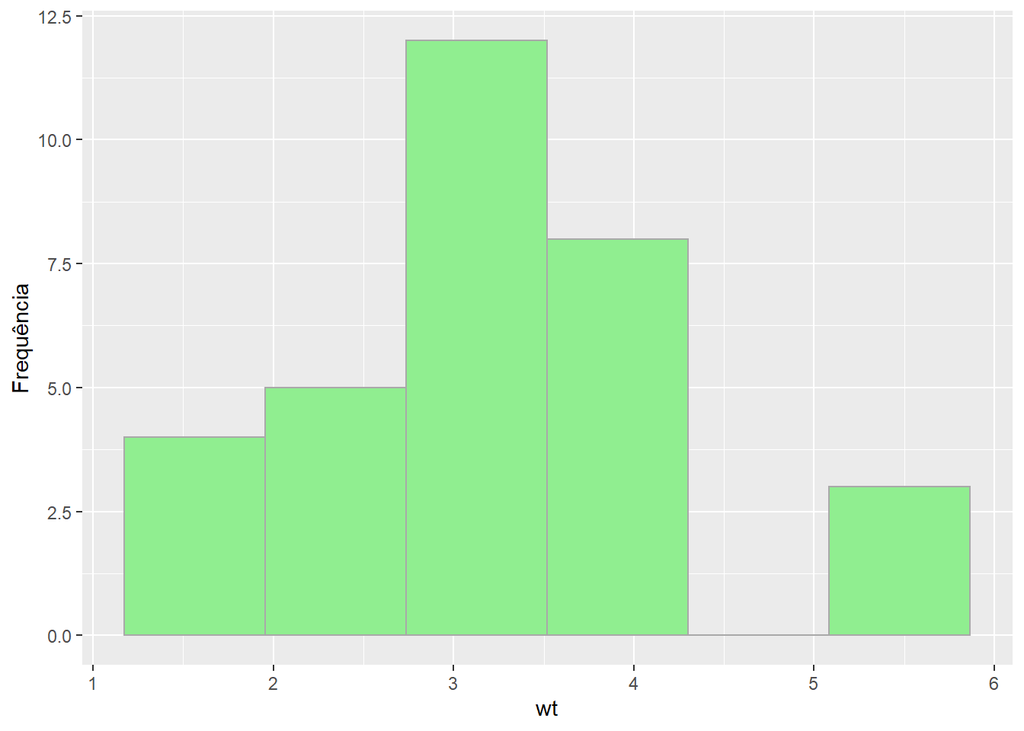

```r
  nbins <- 6

  ggplot(mtcars, aes(x = wt)) +
  geom_histogram(fill = "lightgreen", colour = "darkgrey", bins = nbins) +
  # bins é uma função que declara o número de colunas do gráfico
  ylab("Frequência")
```

ou

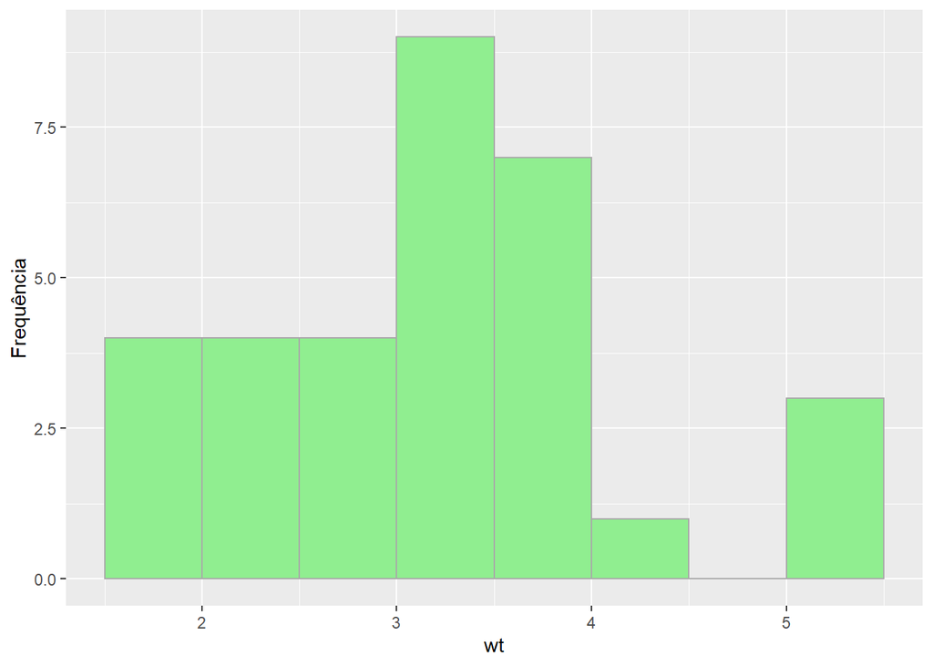

```r
  breaks <- hist(mtcars$wt, plot = F)$breaks

  ggplot(mtcars, aes(x = wt)) +
  geom_histogram(fill = "lightgreen", colour = "darkgrey", breaks = breaks) +
  # `break` é uma função que define o tamanho das classes em cada categoria do gráfico.
  ylab("Frequência")
```

O segundo tipo de gráfico que podemos usar para representar variáveis contínuas é o de Densidade.

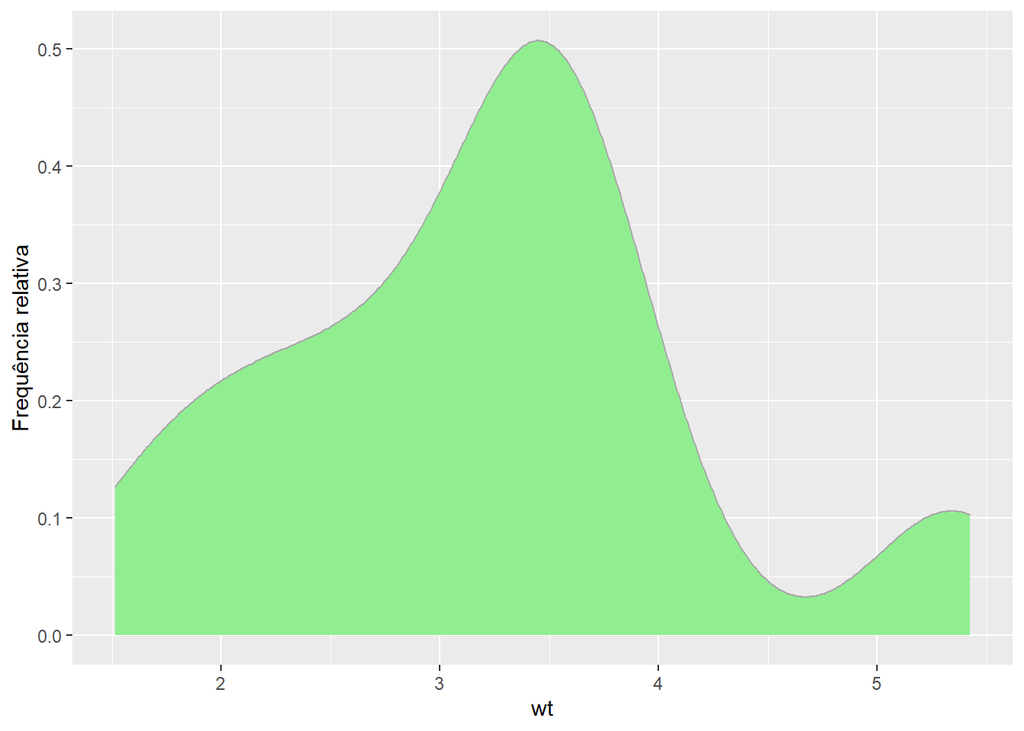

```r
  ggplot(mtcars, aes(x = wt)) +
  geom_density(fill = "lightgreen" ,colour = "darkgrey") +
  # Usamos geom_density para declarar o formato que queremos nosso gráfico: em formato de densidade.
  ylab("Frequência relativa")
```

O terceiro tipo de gráfico que podemos usar para representar variáveis contínuas é o Polígono de Frequência.

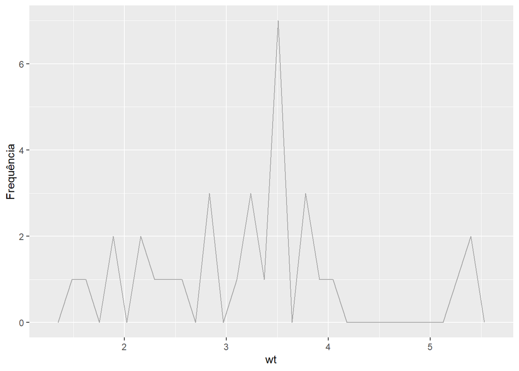

```r
  ggplot(mtcars, aes(x = wt, y = )) +
  geom_freqpoly(colour = "darkgrey", bins = 30) +
  # Usamos geom_freqpoly para declarar o formato que queremos nosso gráfico: em formato de polígono de frequência.
  ylab("Frequência")
```

O quarto tipo de gráfico que podemos usar para representar variáveis contínuas é o Boxplot.

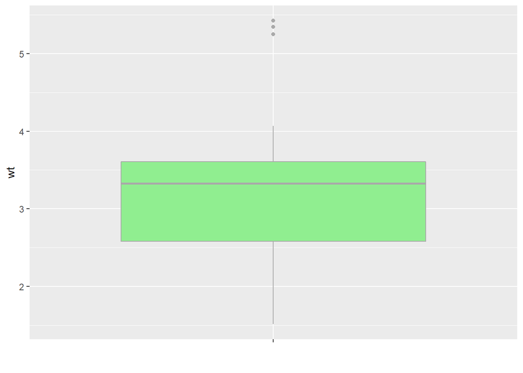

```r
  ggplot(mtcars, aes(x = "", y = wt)) +
  geom_boxplot(fill = "lightgreen", colour = "darkgrey") +
  xlab("")
```

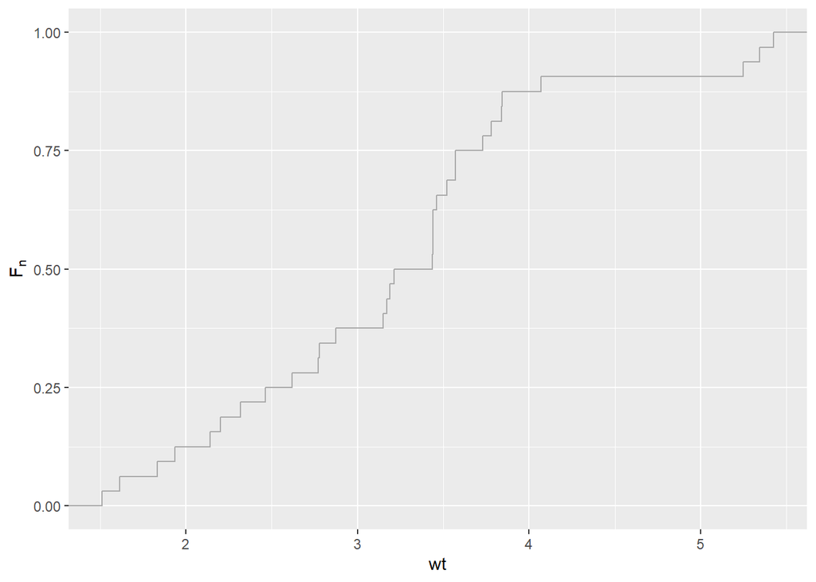

```r
  ggplot(mtcars, aes(wt)) +
  stat_ecdf(geom = "step", colour = "darkgrey") +
  ylab(expression(F[n]))
```

# Gráficos para análise bivariada.

Estivemos até o momento trabalhando com funções univariadas. Agora iremos ver três diferentes situações para plotar gráficos bivariados: Qualitativo X Qualitativa, Qualitativo X Quantitativo, Quantitativo X Quantitativo.

A primeira Situação que iremos ver é o gráfico bivariado Qualitativo X Qualitativo.

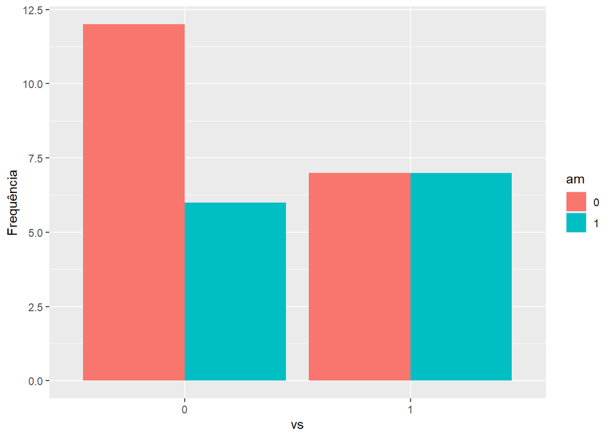

```r
  ggplot(mtcars, aes(x = vs, y = , fill = am)) +
  geom_bar(stat = "count", position = position_dodge()) +
  ylab("Frequência")
```

Veremos agora um gráfico com um Boxplot para cada categoria de uma variável qualitativa.

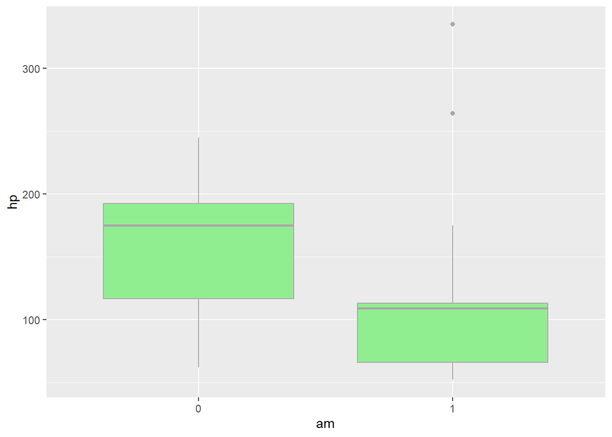

```r
  ggplot(mtcars, aes(x = am, y = hp, group = am)) +
  geom_boxplot( fill = "lightgreen", colour = "darkgrey")
```

Por fim veremos um gráfico de dispersão para duas variáveis quantitativas.

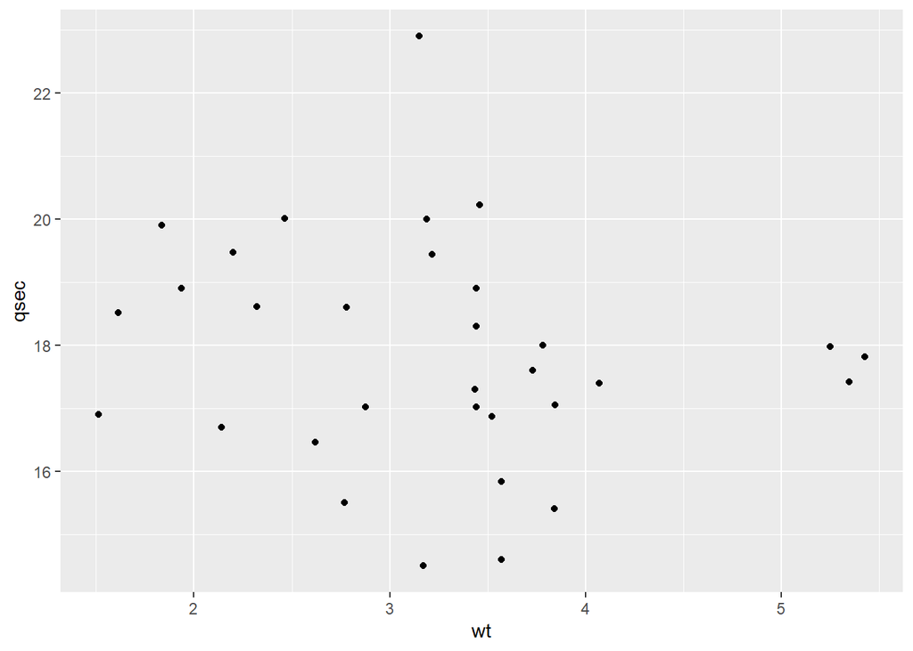

[figure not shown]

```r
  ggplot(mtcars, aes(x = wt, y = qsec)) +
  geom_point(stat = "identity")
```